# Integrated Report: Immigration Policy Attitudes

Ann Jiang

2025-03-17

# Introduction

This report analyzes anti-immigration attitudes using the NSL2018 dataset. The document describes the data preparation steps, presents descriptive analyses (including frequency tables and group comparisons), reports multiple regression models, and displays several visualizations. The goal is to examine how nativity and immigrant generation are associated with anti-immigration attitudes.

# Data Preparation

In this section, we load the required packages, set the working directory, read the dataset, and recode key variables.

```r
# Load required packages
library(dplyr)
library(ggplot2)
library(scales)
library(broom)  # for tidying regression output

# Set working directory and read dataset (update the path accordingly)
setwd("/Users/azure/Desktop/Coursework/PhD Coursework/1.2 Winter 2025/1.2.5 Survey Analysis--Anti-Immigration Immigrant/Pew-Research-Center_2018-National-Survey-of-Latinos-Dataset 2")
nsl_data <- read.csv("NSL2018_data.csv", stringsAsFactors = FALSE)
```

## Recoding Variables

### Nativity

We recode `qn4` so that respondents are flagged as foreign-born (1) if their answer is “another country” (case-insensitive), and U.S.-born (0) otherwise.

```r
nsl_data <- nsl_data %>%
  mutate(foreign_born = ifelse(tolower(trimws(qn4)) == "another country", 1, 0))
```

### Generation Status

Based on the `immgen` variable, we recode generation status as follows:  
- “First Gen FB w/o PR” → “First Gen”  
- “Second Gen NB” → “Second Gen”  
- “Third or more” → “Third+ Gen”  
Other responses become NA.

```r
nsl_data <- nsl_data %>%
  mutate(generation = case_when(
    tolower(trimws(immgen)) == "first gen fb w/o pr" ~ "First Gen",
    tolower(trimws(immgen)) == "second gen nb" ~ "Second Gen",
    tolower(trimws(immgen)) == "third or more" ~ "Third+ Gen",
    TRUE ~ NA_character_
  ))
nsl_data$generation <- factor(nsl_data$generation, levels = c("First Gen", "Second Gen", "Third+ Gen"))
```

### Immigration Policy Indicators

We recode three items: - **qn14a (Trump Support):** 1 if “approve”, 0 if “disapprove”. - **qn29 (Border Wall Favorability):** 1 if “favor”, 0 if “oppose”. - **qn31 (Opinion on Immigrant Population):** 1 if “too many”, 0 if “too few” or “right amount”.

```r
nsl_data <- nsl_data %>%
  mutate(trump_support_bin = case_when(
           tolower(trimws(qn14a)) == "approve" ~ 1,
           tolower(trimws(qn14a)) == "disapprove" ~ 0,
           TRUE ~ NA_real_
         ),
         favor_wall = case_when(
           tolower(trimws(qn29)) == "favor"  ~ 1,
           tolower(trimws(qn29)) == "oppose" ~ 0,
           TRUE ~ NA_real_
         ),
         too_many_imm = case_when(
           tolower(trimws(qn31)) == "too many" ~ 1,
           tolower(trimws(qn31)) %in% c("too few", "right amount") ~ 0,
           TRUE ~ NA_real_
         ))
```

## Composite Variable

We create the composite immigration policy score by summing the three binary indicators. The result is then categorized as a factor with levels 0–3.

```r
nsl_data <- nsl_data %>%
  mutate(immigration_policy = trump_support_bin + favor_wall + too_many_imm,
         immigration_policy_cat = factor(immigration_policy, levels = 0:3, ordered = TRUE))
# Check the composite variable summary
summary(nsl_data$immigration_policy)
```

```
##    Min. 1st Qu.  Median    Mean 3rd Qu.    Max.    NA's
##  0.0000  0.0000  0.0000  0.7738  1.0000  3.0000     356
```

# Descriptive Analyses

In this section, we output summaries, frequency tables, group comparisons, and statistical tests.

## Independent Variables

### Nativity

```r
cat("Nativity (foreign_born):\n")
```

```
## Nativity (foreign_born):
```

```r
print(table(nsl_data$foreign_born, useNA = "ifany"))
```

```
##
##   0   1
## 745 756
```

```r
print(summary(nsl_data$foreign_born))
```

```
##    Min. 1st Qu.  Median    Mean 3rd Qu.    Max.
##  0.0000  0.0000  1.0000  0.5037  1.0000  1.0000
```

### Generation Status

```r
cat("Generation Status (generation):\n")
```

```
## Generation Status (generation):
```

```r
print(table(nsl_data$generation, useNA = "ifany"))
```

```
##
##  First Gen Second Gen Third+ Gen       <NA>
##        759        318        405         19
```

```r
print(summary(nsl_data$generation))
```

```
##  First Gen Second Gen Third+ Gen       NA's
##        759        318        405         19
```

## Dependent Variable

### Composite Immigration Policy

```r
cat("Composite Immigration Policy (immigration_policy):\n")
```

```
## Composite Immigration Policy (immigration_policy):
```

```r
print(summary(nsl_data$immigration_policy))
```

```
##    Min. 1st Qu.  Median    Mean 3rd Qu.    Max.    NA's
##  0.0000  0.0000  0.0000  0.7738  1.0000  3.0000     356
```

```r
cat("\nFrequency Table for immigration_policy_cat:\n")
```

```
##
## Frequency Table for immigration_policy_cat:
```

```r
print(table(nsl_data$immigration_policy_cat, useNA = "ifany"))
```

```
##
##    0    1    2    3 <NA>
##  611  278  160   96  356
```

```r
cat("\nExplanation: NA values in 'immigration_policy_cat' indicate that one or more of the component indicators is missing.\n")
```

```
##
## Explanation: NA values in 'immigration_policy_cat' indicate that one or more of the component indicators is missing.
```

## Group Comparisons

### Mean & SD by Nativity

```r
mean_by_nativity <- nsl_data %>%
  group_by(foreign_born) %>%
  summarise(mean_composite = mean(immigration_policy, na.rm = TRUE),
            sd_composite = sd(immigration_policy, na.rm = TRUE),
            n = n())
cat("Mean and SD of immigration_policy by foreign_born:\n")
```

```
## Mean and SD of immigration_policy by foreign_born:
```

```r
print(mean_by_nativity)
```

```
## # A tibble: 2 × 4
##   foreign_born mean_composite sd_composite     n
##          <dbl>          <dbl>        <dbl> <int>
## 1            0          0.896        1.09    745
## 2            1          0.641        0.820   756
```

### T-Test: Foreign-born vs. U.S.-born

```r
t_test_result <- t.test(immigration_policy ~ foreign_born, data = nsl_data)
cat("T-test for immigration_policy by foreign_born:\n")
```

```
## T-test for immigration_policy by foreign_born:
```

```r
print(t_test_result)
```

```
##
##  Welch Two Sample t-test
##
## data:  immigration_policy by foreign_born
## t = 4.4868, df = 1099.1, p-value = 7.989e-06
## alternative hypothesis: true difference in means between group 0 and group 1 is not equal to 0
## 95 percent confidence interval:
##  0.1433785 0.3662363
## sample estimates:
## mean in group 0 mean in group 1
##       0.8959732       0.6411658
```

### Cross-Tabulations and Chi-Square Tests

```r
cat("Cross-tabulation: Foreign-born vs. immigration_policy_cat:\n")
```

```
## Cross-tabulation: Foreign-born vs. immigration_policy_cat:
```

```r
cross_tab <- table(nsl_data$foreign_born, nsl_data$immigration_policy_cat)
print(cross_tab)
```

```
##
##       0   1   2   3
##   0 312 111  96  77
##   1 299 167  64  19
```

```r
cat("\nChi-square Test (Foreign-born vs. immigration_policy_cat):\n")
```

```
##
## Chi-square Test (Foreign-born vs. immigration_policy_cat):
```

```r
chi_sq_result <- chisq.test(cross_tab)
print(chi_sq_result)
```

```
##
##  Pearson's Chi-squared test
##
## data:  cross_tab
## X-squared = 51.156, df = 3, p-value = 4.532e-11
```

```r
cat("\nCross-tabulation: Generation vs. immigration_policy_cat:\n")
```

```
##
## Cross-tabulation: Generation vs. immigration_policy_cat:
```

```r
cross_tab_gen <- table(nsl_data$generation, nsl_data$immigration_policy_cat)
print(cross_tab_gen)
```

```
##
##                0   1   2   3
##   First Gen  301 167  64  20
##   Second Gen 145  56  39  22
##   Third+ Gen 159  54  54  52
```

```r
cat("\nChi-square Test (Generation vs. immigration_policy_cat):\n")
```

```
##
## Chi-square Test (Generation vs. immigration_policy_cat):
```

```r
chi_sq_gen <- chisq.test(cross_tab_gen)
print(chi_sq_gen)
```

```
##
##  Pearson's Chi-squared test
##
## data:  cross_tab_gen
## X-squared = 60.654, df = 6, p-value = 3.314e-11
```

# Regression Analyses

We run three models: one with nativity only, one with generation among U.S.-born respondents, and one using a combined categorical variable.

## Separate Models

### Model 1: Immigration Policy ~ Nativity

```r
model_nat <- lm(immigration_policy ~ foreign_born, data = nsl_data)
cat("Regression Model: Immigration Policy ~ Nativity\n")
```

```
## Regression Model: Immigration Policy ~ Nativity
```

```r
print(summary(model_nat))
```

```
##
## Call:
## lm(formula = immigration_policy ~ foreign_born, data = nsl_data)
##
## Residuals:
##     Min      1Q  Median      3Q     Max
## -0.8960 -0.8960 -0.6412  0.3588  2.3588
##
## Coefficients:
##              Estimate Std. Error t value Pr(>|t|)
## (Intercept)   0.89597    0.03978  22.525  < 2e-16 ***
## foreign_born -0.25481    0.05744  -4.436 1.01e-05 ***
## ---
## Signif. codes:  0 '***' 0.001 '**' 0.01 '*' 0.05 '.' 0.1 ' ' 1
##
## Residual standard error: 0.9711 on 1143 degrees of freedom
##   (356 observations deleted due to missingness)
## Multiple R-squared:  0.01692,    Adjusted R-squared:  0.01606
## F-statistic: 19.68 on 1 and 1143 DF,  p-value: 1.006e-05
```

### Model 2: Immigration Policy ~ Generation (U.S.-born only)

```r
nsl_usborn <- subset(nsl_data, foreign_born == 0)
model_gen <- lm(immigration_policy ~ generation, data = nsl_usborn)
cat("Regression Model: Immigration Policy ~ Generation (U.S.-born only)\n")
```

```
## Regression Model: Immigration Policy ~ Generation (U.S.-born only)
```

```r
print(summary(model_gen))
```

```
##
## Call:
## lm(formula = immigration_policy ~ generation, data = nsl_usborn)
##
## Residuals:
##     Min      1Q  Median      3Q     Max
## -1.0000 -0.9969 -0.7634  1.0031  2.2366
##
## Coefficients:
##                       Estimate Std. Error t value Pr(>|t|)
## (Intercept)           1.000000   0.626589   1.596    0.111
## generationSecond Gen -0.236641   0.630166  -0.376    0.707
## generationThird+ Gen -0.003135   0.629528  -0.005    0.996
##
## Residual standard error: 1.085 on 581 degrees of freedom
##   (161 observations deleted due to missingness)
## Multiple R-squared:  0.01138,    Adjusted R-squared:  0.007979
## F-statistic: 3.345 on 2 and 581 DF,  p-value: 0.03596
```

## Combined Categorical Variable

We create a combined variable that assigns “Foreign-born (First Gen)” if foreign_born == 1, and uses the generation value for U.S.-born respondents.

```r
nsl_data <- nsl_data %>%
  mutate(nativity_generation = ifelse(foreign_born == 1, "Foreign-born (First Gen)", as.character(generation)))
nsl_data$nativity_generation <- factor(nsl_data$nativity_generation, levels = c("Foreign-born (First Gen)", "Second Gen", "Third+ Gen"))
cat("Combined Nativity/Generation Variable Distribution:\n")
```

```
## Combined Nativity/Generation Variable Distribution:
```

```r
print(table(nsl_data$nativity_generation, useNA = "ifany"))
```

```
##
## Foreign-born (First Gen)               Second Gen               Third+ Gen
##                      756                      318                      405
##                     <NA>
##                       22
```

```r
model_combined <- lm(immigration_policy ~ nativity_generation, data = nsl_data)
cat("Regression Model: Immigration Policy ~ Combined Nativity/Generation\n")
```

```
## Regression Model: Immigration Policy ~ Combined Nativity/Generation
```

```r
print(summary(model_combined))
```

```
##
## Call:
## lm(formula = immigration_policy ~ nativity_generation, data = nsl_data)
##
## Residuals:
##     Min      1Q  Median      3Q     Max
## -0.9969 -0.7634 -0.6412  0.3588  2.3588
##
## Coefficients:
##                               Estimate Std. Error t value Pr(>|t|)
## (Intercept)                    0.64117    0.04113  15.589  < 2e-16 ***
## nativity_generationSecond Gen  0.12219    0.07236   1.689   0.0916 .
## nativity_generationThird+ Gen  0.35570    0.06784   5.243 1.89e-07 ***
## ---
## Signif. codes:  0 '***' 0.001 '**' 0.01 '*' 0.05 '.' 0.1 ' ' 1
##
## Residual standard error: 0.9637 on 1127 degrees of freedom
##   (371 observations deleted due to missingness)
## Multiple R-squared:  0.02382,    Adjusted R-squared:  0.02209
## F-statistic: 13.75 on 2 and 1127 DF,  p-value: 1.257e-06
```

# Visualizations

## Bar Chart: Mean Composite Score by Nativity/Generation

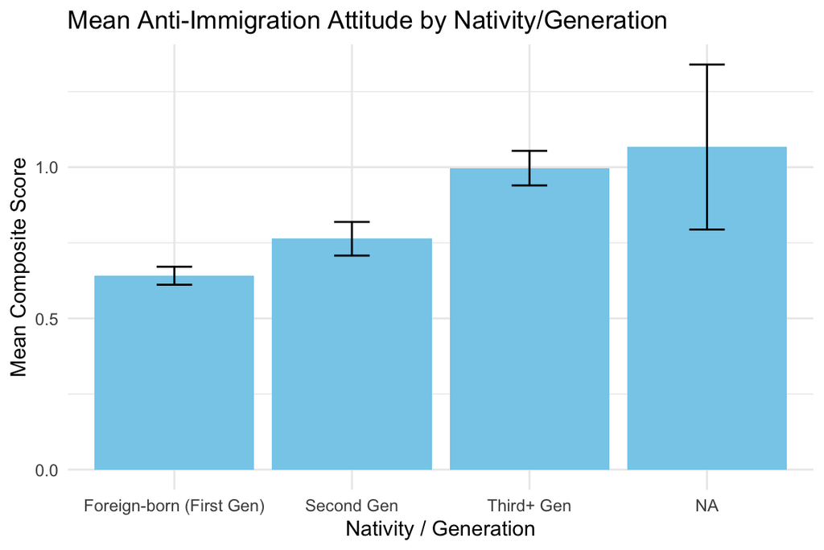

```r
mean_data <- nsl_data %>%
  group_by(nativity_generation) %>%
  summarise(mean_policy = mean(immigration_policy, na.rm = TRUE),
            se_policy = sd(immigration_policy, na.rm = TRUE) / sqrt(n()),
            n = n())

ggplot(mean_data, aes(x = nativity_generation, y = mean_policy)) +
  geom_bar(stat = "identity", fill = "skyblue") +
  geom_errorbar(aes(ymin = mean_policy - se_policy, ymax = mean_policy + se_policy), width = 0.2) +
  labs(title = "Mean Anti-Immigration Attitude by Nativity/Generation",
       x = "Nativity / Generation",
       y = "Mean Composite Score") +
  theme_minimal()
```

## Stacked Bar Chart: Distribution of Composite Scores

We calculate percentages in the natural order (0 to 3) and then plot a stacked bar chart.

[figure not shown]

```r
dist_data <- nsl_data %>%
  filter(!is.na(nativity_generation), !is.na(immigration_policy_cat)) %>%
  group_by(nativity_generation, immigration_policy_cat) %>%
  summarise(count = n(), .groups = "drop") %>%
  group_by(nativity_generation) %>%
  mutate(
    percentage = count / sum(count) * 100,
    label_pos = cumsum(percentage) - 0.5 * percentage,
    sample_size = sum(count)
  ) %>%
  arrange(nativity_generation, immigration_policy_cat)

my_palette <- c(
  "0" = "#F0E442",  # Yellow
  "1" = "#009E73",  # Green
  "2" = "#56B4E9",  # Blue
  "3" = "#E69F00"   # Orange
)

ggplot(dist_data, aes(x = nativity_generation, y = percentage, fill = immigration_policy_cat)) +
  geom_bar(stat = "identity", width = 0.7, position = "stack") +
  geom_text(aes(y = label_pos, label = sprintf("%.1f%%", percentage)),
            color = "black", size = 3.5,
            data = subset(dist_data, percentage > 7)) +
  scale_fill_manual(
    values = my_palette,
    name = "Anti-Immigration\nAttitude Score",
    labels = c("0 (Low)", "1", "2", "3 (High)")
  ) +
  labs(
    title = "Distribution of Anti-Immigration Attitudes by Nativity/Generation",
    subtitle = "Score=0 is at the bottom, Score=3 is at the top",
    x = "",
    y = "Percentage of Respondents",
    caption = "Groups: Foreign-born (First Gen), Second Gen, Third+ Gen"
  ) +
  scale_y_continuous(limits = c(0, 100), labels = percent_format(scale = 1)) +
  theme_minimal() +
  theme(
    legend.position = "right",
    plot.title = element_text(face = "bold", size = 14),
    plot.subtitle = element_text(size = 11, color = "#636363"),
    plot.caption = element_text(size = 9, color = "#636363", hjust = 0),
    axis.text = element_text(size = 10),
    axis.title.y = element_text(size = 11),
    panel.grid.minor = element_blank()
  ) +
  geom_text(aes(y = -5, label = paste0("n=", sample_size)),
            size = 3, color = "#636363")
```

## Regression Coefficient Plot

We visualize the coefficients from the combined categorical model.

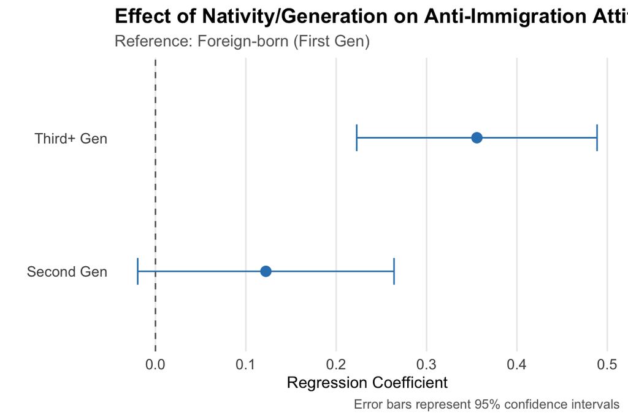

```r
coef_data <- tidy(model_combined)
# Exclude the intercept for clarity
coef_data <- coef_data[coef_data$term != "(Intercept)", ]
# Clean term labels
coef_data$term <- gsub("nativity_generation", "", coef_data$term)

ggplot(coef_data, aes(x = estimate, y = reorder(term, estimate))) +
  geom_vline(xintercept = 0, linetype = "dashed", color = "#636363") +
  geom_point(size = 3, color = "#3182bd") +
  geom_errorbarh(aes(xmin = estimate - 1.96 * std.error, xmax = estimate + 1.96 * std.error),
                 height = 0.2, color = "#3182bd") +
  labs(
    title = "Effect of Nativity/Generation on Anti-Immigration Attitudes",
    subtitle = "Reference: Foreign-born (First Gen)",
    x = "Regression Coefficient",
    y = "",
    caption = "Error bars represent 95% confidence intervals"
  ) +
  theme_minimal() +
  theme(
    plot.title = element_text(face = "bold", size = 14),
    plot.subtitle = element_text(size = 11, color = "#636363"),
    plot.caption = element_text(size = 9, color = "#636363"),
    axis.title.x = element_text(size = 11),
    axis.text = element_text(size = 10),
    panel.grid.minor = element_blank(),
    panel.grid.major.y = element_blank()
  )
```

# Conclusion

This report has provided a comprehensive overview of the analysis of anti-immigration attitudes: - **Descriptive statistics** were generated for key independent and dependent variables. - **Group comparisons** (means, t-tests, cross-tabulations, and chi-square tests) were performed. - **Regression models** were run using separate and combined approaches to examine the influence of nativity and generation. - **Visualizations** including bar charts, stacked bar charts, and a regression coefficient plot are provided for clear interpretation of the results.

==========================================================================

# End of Report

[output not shown]